# 누가 온라인 개인정보 침해를 더 두려워하는가? 랜덤포레스트를 활용한 프라이버시 염려 예측 및 고위험군 분류 분석

Author

박성준

Published

November 25, 2026

# Background: 대한민국은 디지털 혁신을 확산하기 위해 디지털 뉴딜(Digital New Deal) 정책을 추진했고, 디지털 대전환(Digital Transformation)을 맞이하고 있다. 이에 국회에서 2024년 12월 26일날 AI 기본법을 의결하였고, 국가 차원에서 인공지능 거버넌스 체계를 정립하고 인공지능 산업 육성 및 인공지능으로부터 발생할 수 있는 위험을 사전에 예방하고자 한다. 시민들의 개인 맞춤형 서비스를 제공받기 위해서 인공지능 활용이 증가했고, 개인정보 제공은 무분별하고 무의식적으로 제공되고 있다. 특히 최근 쿠팡과 티빙 등 기업에서 개인정보 유출 사고가 빈번히 발생되면서, 시민들의 개인정보 도용에 대한 우려가 점차 증가되고, 정부와 국회에서 논의가 본격적으로 시작되고 있다. 이에, 본 연구는 랜덤포레스트를 활용해서 온라인 개인정보 침해 염려에 대해 분류형과 연속형으로 각각 분석하고자 한다. 연속형으로 온라인 개인정보 침해 염려에 대한 예측요인을 탐색하고, 분류형으로 고위험군(개인정보 침해 염려 수준이 높은 집단)으로 분류되는 요인을 탐색하고자 한다.

# Result: Random Forest

```r
library(dplyr)
library(tidyr)
library(tibble)
library(ggplot2)
library(rpart)
library(ipred)
library(ranger)
library(tidymodels)
library(readr)
library(doParallel)

file_path <- "c:/data_ml2.csv"

ohie <- read_csv(file_path)

if (inherits(ohie, "data.table")) ohie <- as.data.frame(ohie)

summary(ohie$privacy)
```

```
   Min. 1st Qu.  Median    Mean 3rd Qu.    Max.
  1.000   3.400   4.000   3.872   4.400   5.000
```

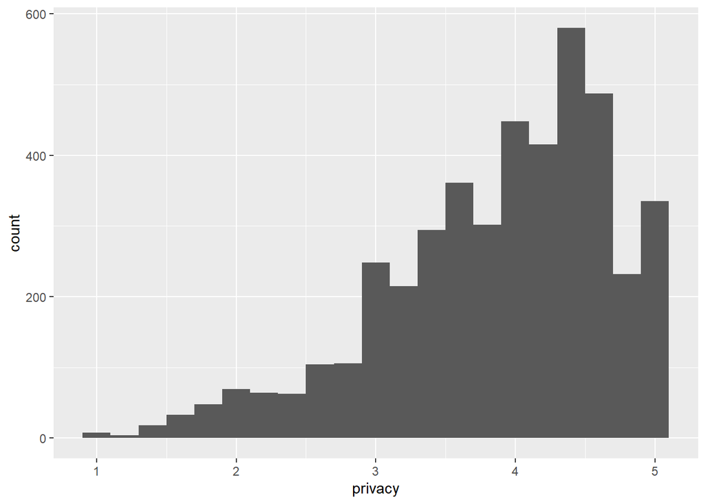

```r
ggplot(ohie, aes(x = privacy)) + geom_histogram(binwidth = 0.2)
```

```r
cut <- quantile(ohie$privacy, 0.75)

required_vars <- c(
  "area", "gender", "age", "school", "income", "snsuse", "snspublic", "snsshare", "snsmap", "cloud", "meta", "aiknow",
  "aiuse", "com_tv", "com_mall", "com_aboard", "com_person", "com_bank", "com_trans", "com_buy", "oneline", "capa_base",
  "capa_master", "capa_security", "liter", "werable", "self", "pol_part", "politic", "emotion")

stopifnot(all(required_vars %in% names(ohie)))

ohie <- ohie |>
  mutate(privacy_high = factor(if_else(privacy >= cut, "high", "low"), levels = c("high", "low")),
  area = factor(area),
  gender = factor(gender)) |>
  select(privacy, privacy_high, all_of(required_vars))

prop.table(table(ohie$privacy_high))
```

```
    high      low
0.368516 0.631484
```

```r
set.seed(42)
split <- initial_split(ohie, prop=0.7, strata = privacy_high)
train <- training(split)
folds <- vfold_cv(train, v = 5, strata = privacy_high)

rec_r <- recipe(privacy ~ ., data = train) |>
  step_rm(privacy_high)

rf_r <- rand_forest(trees = 500, mtry = tune(), min_n = tune()) |>
  set_engine("ranger", importance = "permutation") |>
  set_mode("regression")

wf_r <- workflow() |> add_recipe(rec_r) |> add_model(rf_r)

params_r <- extract_parameter_set_dials(wf_r) |>
  update(mtry = mtry(c(3L, 15L)), min_n = min_n(c(5L, 40L)))

set.seed(42)
tuned_r <- tune_grid(
  wf_r, resamples = folds, param_info = params_r, grid = 20,
  metrics = metric_set(rmse, rsq, mae)
)

show_best(tuned_r, metric = "rmse")
```

```
# A tibble: 5 × 8
   mtry min_n .metric .estimator  mean     n std_err .config
  <int> <int> <chr>   <chr>      <dbl> <int>   <dbl> <chr>
1     7     5 rmse    standard   0.650     5 0.00736 pre0_mod09_post0
2    11     6 rmse    standard   0.651     5 0.00814 pre0_mod16_post0
3     8    10 rmse    standard   0.654     5 0.00656 pre0_mod11_post0
4    14    12 rmse    standard   0.654     5 0.00776 pre0_mod19_post0
5     9    17 rmse    standard   0.655     5 0.00708 pre0_mod13_post0
```

```r
sd(ohie$privacy)
```

```
[1] 0.8095882
```

```r
1 - (0.650 / sd(ohie$privacy))^2
```

```
[1] 0.355388
```

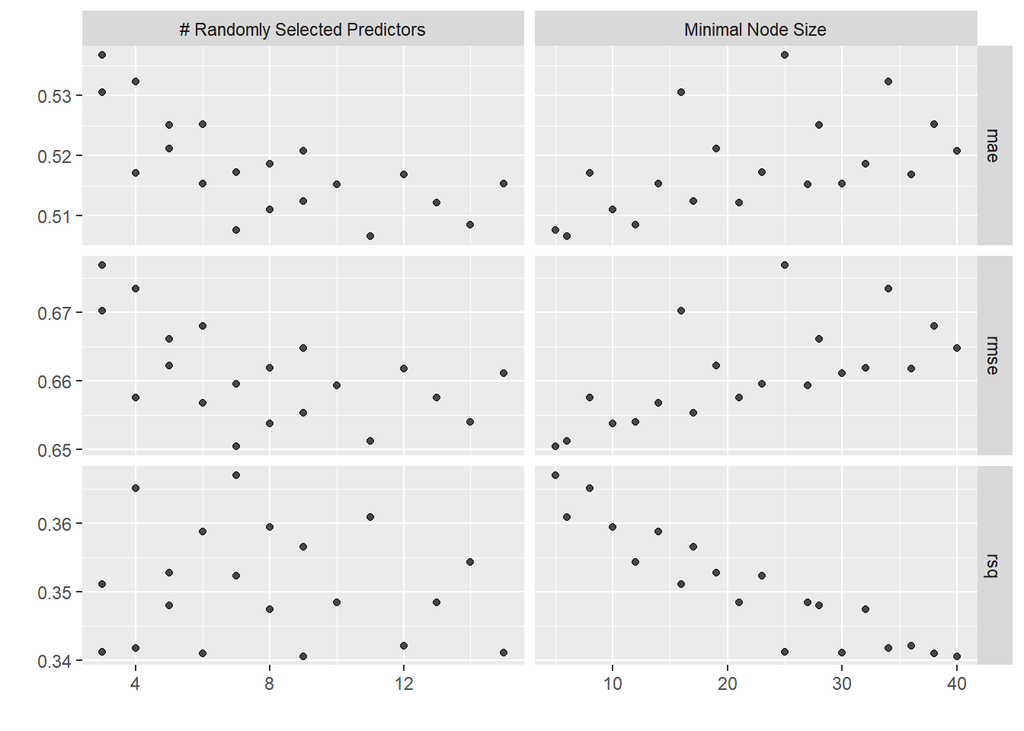

```r
autoplot(tuned_r)
```

```r
best_r <- select_best(tuned_r, metric = "rmse")
fit_r <- last_fit(finalize_workflow(wf_r, best_r), split, metrics = metric_set(rmse, rsq, mae))
collect_metrics(fit_r)
```

```
# A tibble: 3 × 4
  .metric .estimator .estimate .config
  <chr>   <chr>          <dbl> <chr>
1 rmse    standard       0.640 pre0_mod0_post0
2 rsq     standard       0.385 pre0_mod0_post0
3 mae     standard       0.496 pre0_mod0_post0
```

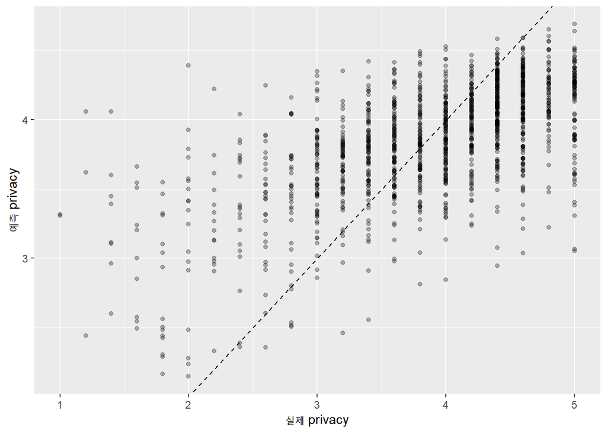

```r
collect_predictions(fit_r) |>
  ggplot(aes(x = privacy, y = .pred)) +
  geom_point(alpha = 0.3) +
  geom_abline(linetype = 'dashed') +
  labs(x = "실제 privacy", y = "예측 privacy")
```

```r
imp_r <- extract_fit_engine(fit_r)$variable.importance

imp_r_df <- tibble(variable = names(imp_r), importance = imp_r) |>
  arrange(desc(importance))

imp_r_df |> print(n = 30)   # 전체 수치 확인
```

```
# A tibble: 30 × 2
   variable      importance
   <chr>              <dbl>
 1 liter           0.199
 2 emotion         0.0755
 3 capa_master     0.0635
 4 oneline         0.0444
 5 capa_base       0.0342
 6 area            0.0324
 7 snspublic       0.0308
 8 pol_part        0.0249
 9 com_buy         0.0246
10 snsmap          0.0243
11 snsuse          0.0206
12 capa_security   0.0185
```

[output cut: 18 more lines]

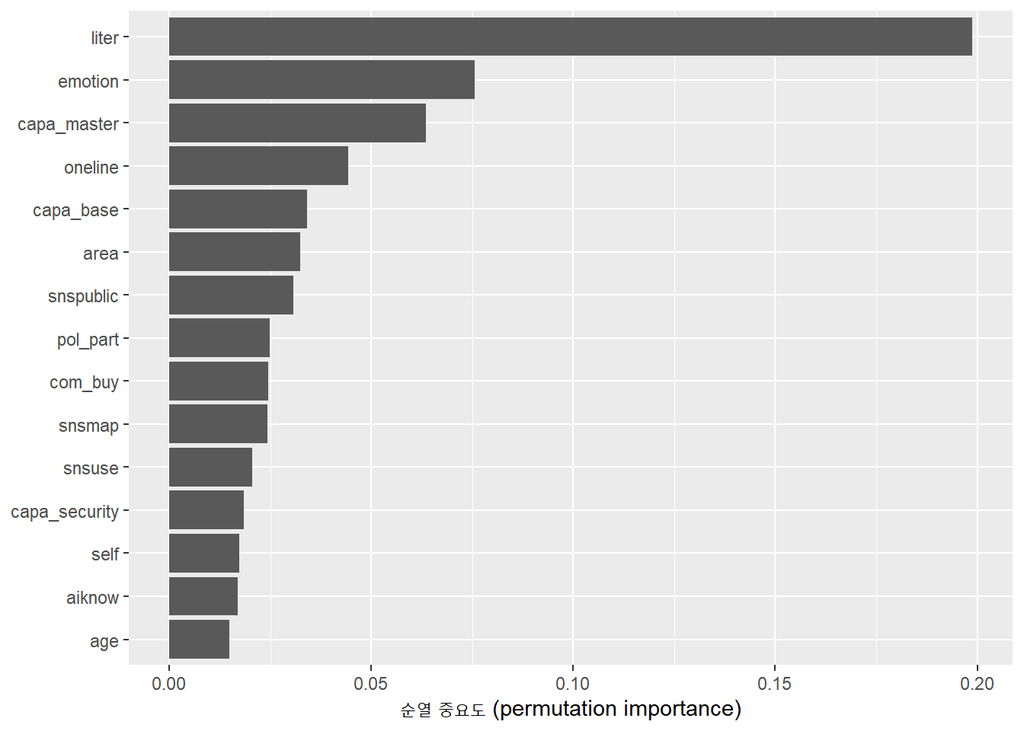

```r
imp_r_df |>
  slice_head(n = 15) |>
  ggplot(aes(x = importance, y = reorder(variable, importance))) +
  geom_col() +
  labs(x = "순열 중요도 (permutation importance)", y = NULL)
```

```r
collect_metrics(fit_r)
```

```
# A tibble: 3 × 4
  .metric .estimator .estimate .config
  <chr>   <chr>          <dbl> <chr>
1 rmse    standard       0.640 pre0_mod0_post0
2 rsq     standard       0.385 pre0_mod0_post0
3 mae     standard       0.496 pre0_mod0_post0
```

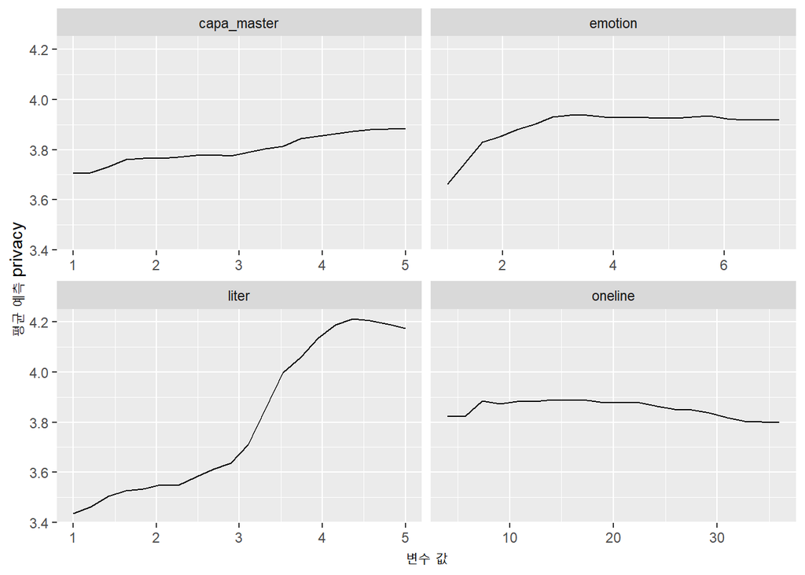

```r
wf_fit <- extract_workflow(fit_r)

pdp_one <- function(var) {
  x <- sort(unique(train[[var]]))
  if (length(x) > 20) x <- seq(min(x), max(x), length.out = 20)
  map_dfr(x, \(v) {
    d <- train
    d[[var]] <- v
    tibble(variable = var, value = v, pred = mean(predict(wf_fit, d)$.pred))
  })
}

pdp_df <- map_dfr(c("liter", "emotion", "capa_master", "oneline"), pdp_one)

ggplot(pdp_df, aes(value, pred)) +
  geom_line() +
  facet_wrap(~ variable, scales = "free_x") +
  labs(x = "변수 값", y = "평균 예측 privacy")
```

```r
rec_lm <- recipe(privacy ~ ., data = train) |>
  step_rm(privacy_high) |>
  step_dummy(all_nominal_predictors()) |>
  step_zv(all_predictors())

wf_lm <- workflow() |> add_recipe(rec_lm) |> add_model(linear_reg())

fit_lm <- last_fit(wf_lm, split, metrics = metric_set(rmse, rsq, mae))
collect_metrics(fit_lm)    # 랜덤포레스트(0.640, 0.385)와 비교
```

```
# A tibble: 3 × 4
  .metric .estimator .estimate .config
  <chr>   <chr>          <dbl> <chr>
1 rmse    standard       0.700 pre0_mod0_post0
2 rsq     standard       0.251 pre0_mod0_post0
3 mae     standard       0.552 pre0_mod0_post0
```

```r
rec_c <- recipe(privacy_high ~ ., data = train) |>
  step_rm(privacy)

# 튜닝용 모델 (중요도 계산 없음)
rf_c <- rand_forest(trees = 300, mtry = tune(), min_n = tune()) |>
  set_engine("ranger", num.threads = 1) |>
  set_mode("classification")

wf_c <- workflow() |> add_recipe(rec_c) |> add_model(rf_c)

params_c <- dials::parameters(
  dials::mtry(range = c(3L, 15L)),
  dials::min_n(range = c(5L, 40L))
)

# 병렬 처리
cl <- makePSOCKcluster(parallel::detectCores() - 1)
registerDoParallel(cl)

cls_tune_metrics <- metric_set(
  yardstick::roc_auc, yardstick::pr_auc,
  yardstick::sens, yardstick::spec, yardstick::f_meas
)

set.seed(42)
tuned_c <- tune_grid(
  wf_c, resamples = folds, param_info = params_c, grid = 20,
  metrics = cls_tune_metrics,
  control = control_grid(verbose = TRUE)
)

stopCluster(cl)

show_best(tuned_c, metric = "roc_auc")
```

```
# A tibble: 5 × 8
   mtry min_n .metric .estimator  mean     n std_err .config
  <int> <int> <chr>   <chr>      <dbl> <int>   <dbl> <chr>
1     7     5 roc_auc binary     0.797     5 0.00651 pre0_mod09_post0
2    11     6 roc_auc binary     0.796     5 0.00545 pre0_mod16_post0
3     6    14 roc_auc binary     0.794     5 0.00636 pre0_mod07_post0
4     8    10 roc_auc binary     0.794     5 0.00634 pre0_mod11_post0
5     4     8 roc_auc binary     0.793     5 0.00635 pre0_mod03_post0
```

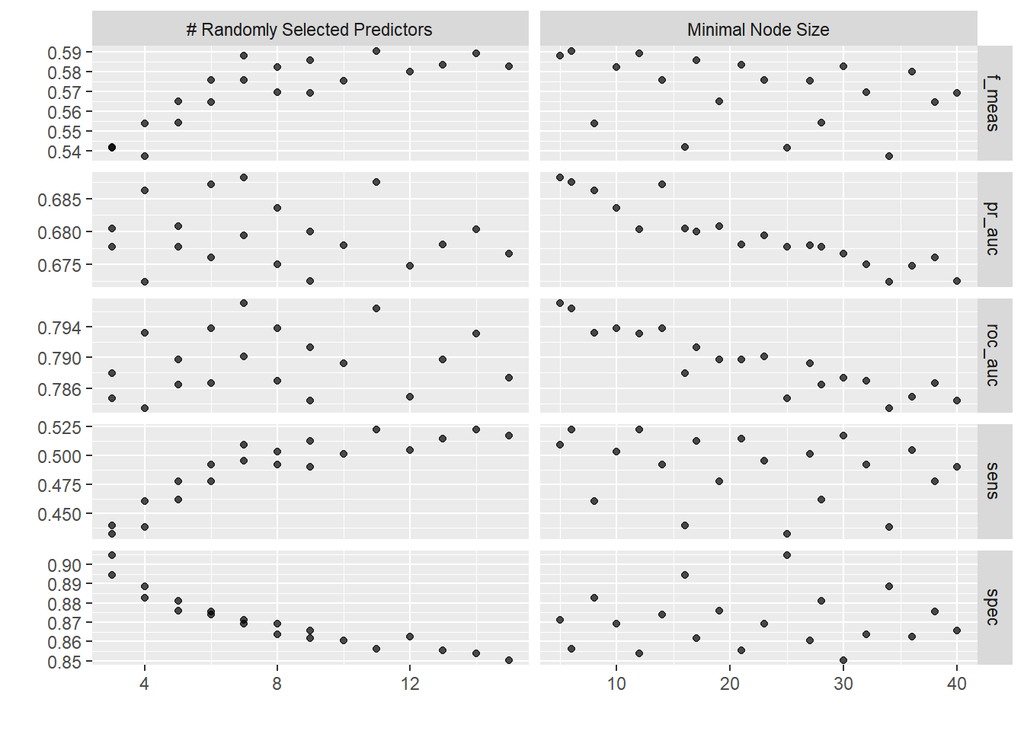

```r
autoplot(tuned_c)
```

```r
best_c <- select_best(tuned_c, metric = "roc_auc")
best_c
```

```
# A tibble: 1 × 3
   mtry min_n .config
  <int> <int> <chr>
1     7     5 pre0_mod09_post0
```

```r
final_c <- finalize_workflow(wf_c, best_c) |>
  update_model(
    rand_forest(trees = 500, mtry = best_c$mtry, min_n = best_c$min_n) |>
      set_engine("ranger", importance = "permutation") |>
      set_mode("classification")
  )

cls_metrics <- metric_set(
  yardstick::roc_auc, yardstick::pr_auc, yardstick::accuracy,
  yardstick::sens, yardstick::spec, yardstick::f_meas
)

fit_c <- last_fit(final_c, split, metrics = cls_metrics)
collect_metrics(fit_c)
```

```
# A tibble: 6 × 4
  .metric  .estimator .estimate .config
  <chr>    <chr>          <dbl> <chr>
1 accuracy binary         0.751 pre0_mod0_post0
2 sens     binary         0.538 pre0_mod0_post0
3 spec     binary         0.875 pre0_mod0_post0
4 f_meas   binary         0.614 pre0_mod0_post0
5 roc_auc  binary         0.804 pre0_mod0_post0
6 pr_auc   binary         0.697 pre0_mod0_post0
```

```r
pred_c <- collect_predictions(fit_c)
conf_mat(pred_c, truth = privacy_high, estimate = .pred_class)
```

```
          Truth
Prediction high low
      high  264 105
      low   227 736
```

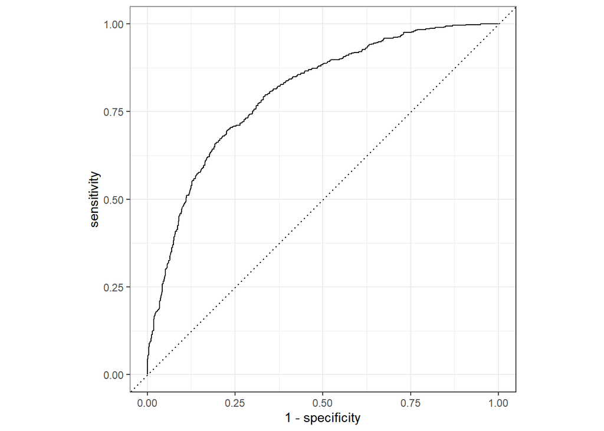

```r
roc_curve(pred_c, truth = privacy_high, .pred_high) |> autoplot()
```

```r
rec_glm <- recipe(privacy_high ~ ., data = train) |>
  step_rm(privacy) |>
  step_dummy(all_nominal_predictors()) |>
  step_zv(all_predictors())

wf_glm <- workflow() |> add_recipe(rec_glm) |> add_model(logistic_reg())

fit_glm <- last_fit(wf_glm, split, metrics = cls_metrics)
collect_metrics(fit_glm)
```

```
# A tibble: 6 × 4
  .metric  .estimator .estimate .config
  <chr>    <chr>          <dbl> <chr>
1 accuracy binary         0.714 pre0_mod0_post0
2 sens     binary         0.477 pre0_mod0_post0
3 spec     binary         0.853 pre0_mod0_post0
4 f_meas   binary         0.551 pre0_mod0_post0
5 roc_auc  binary         0.738 pre0_mod0_post0
6 pr_auc   binary         0.610 pre0_mod0_post0
```

```r
imp_c <- extract_fit_engine(fit_c)$variable.importance

imp_c_df <- tibble(variable = names(imp_c), importance = imp_c) |>
  arrange(desc(importance))

imp_c_df |> print(n = 30)
```

```
# A tibble: 30 × 2
   variable        importance
   <chr>                <dbl>
 1 liter          0.0638
 2 capa_master    0.0146
 3 emotion        0.0111
 4 pol_part       0.00935
 5 capa_base      0.00934
 6 area           0.00781
 7 oneline        0.00686
 8 self           0.00657
 9 capa_security  0.00619
10 snsuse         0.00541
11 aiknow         0.00526
12 politic        0.00284
```

[output cut: 18 more lines]

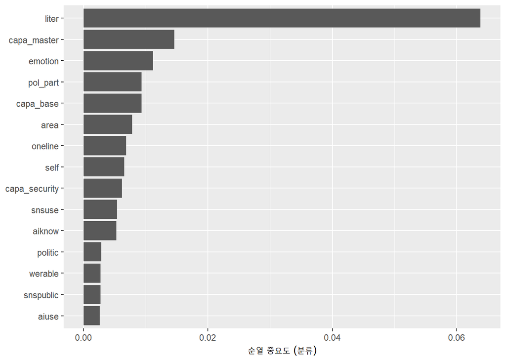

```r
imp_c_df |>
  slice_head(n = 15) |>
  ggplot(aes(x = importance, y = reorder(variable, importance))) +
  geom_col() +
  labs(x = "순열 중요도 (분류)", y = NULL)
```

```r
# 회귀와 분류의 순위 비교
imp_r_df |>
  mutate(rank_reg = row_number()) |>
  select(variable, rank_reg) |>
  inner_join(imp_c_df |> mutate(rank_cls = row_number()) |> select(variable, rank_cls),
             by = "variable") |>
  arrange(rank_reg) |>
  print(n = 15)
```

```
# A tibble: 30 × 3
   variable      rank_reg rank_cls
   <chr>            <int>    <int>
 1 liter                1        1
 2 emotion              2        3
 3 capa_master          3        2
 4 oneline              4        7
 5 capa_base            5        5
 6 area                 6        6
 7 snspublic            7       14
 8 pol_part             8        4
 9 com_buy              9       18
10 snsmap              10       17
11 snsuse              11       10
12 capa_security       12        9
13 self                13        8
14 aiknow              14       11
15 age                 15       22
# ℹ 15 more rows
```

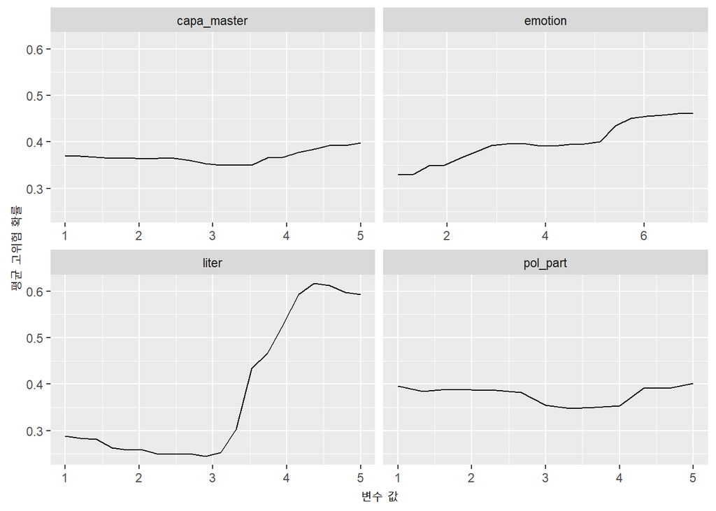

```r
wf_fit_c <- extract_workflow(fit_c)

pdp_one_c <- function(var) {
  x <- sort(unique(train[[var]]))
  if (length(x) > 20) x <- seq(min(x), max(x), length.out = 20)
  map_dfr(x, \(v) {
    d <- train
    d[[var]] <- v
    tibble(variable = var, value = v,
           pred = mean(predict(wf_fit_c, d, type = "prob")$.pred_high))
  })
}

top4 <- head(imp_c_df$variable, 4)
pdp_c <- map_dfr(top4, pdp_one_c)

ggplot(pdp_c, aes(value, pred)) +
  geom_line() +
  facet_wrap(~ variable, scales = "free_x") +
  labs(x = "변수 값", y = "평균 고위험 확률")
```